# VAST index workflow

Sarah Gaichas and Sean Lucey

2024-05-30

# Introduction

We used stomach contents data to estimate an index of forage fish biomass for the 2023 state of the ecosystem reports and the bluefish stock assessment. Here, we extend that idea to estimate an index of benthic group biomass for use in fitting food web models of the Gulf of Maine (GOM) and George Bank (GB).

The basic workflow is to develop a dataset of stomach contents data where fish predators act as samplers of the prey field, then fit a vector autoregressive spatio-temporal (VAST) model to this dataset to generate an index.

# Data

## Which prey?

Sean has mapped the food habits categories to Rpath categories. We want indices for the benthic categories Megafauna and Macrofauna in the GB and GOM Rpath models.

Upon review of these categories and model input data by Sean and Sarah Weisberg, two changes were made from the original list.

- The prey “PECTINIDAE”, “PECTINIDAE SHELL”, “PECTINIDAE VISCERA” were removed from macrobenthos and added to the AtlScallop group, as they likely represent sea scallops identified in stomachs. Therefore these prey categories will not be included in the benthos indices.
- The prey “ALBUNEA PARETII”, “EMERITA TALPOIDA”, “RANILIA MURICATA”, “HIPPIDAE” were removed from megabenthos and added to macrobenthos, because these are small sand crabs and mole crabs.

All tables in this document have been adjusted to reflect these changes.

```r
# object is called prey
load(here("data/prey.RData")) #original mappings from June 2023

addtomacro <- prey |>
  dplyr::filter(RPATH == "Megabenthos") |>
  dplyr::filter(PYNAM %in% c("ALBUNEA PARETII", "EMERITA TALPOIDA", "RANILIA MURICATA", "HIPPIDAE"))

megaben <- prey |>
  dplyr::filter(RPATH == "Megabenthos") |>
  dplyr::filter(!PYNAM %in% c("ALBUNEA PARETII", "EMERITA TALPOIDA", "RANILIA MURICATA", "HIPPIDAE"))

macroben <- prey |>
  dplyr::filter(RPATH == "Macrobenthos") |>
  dplyr::filter(!PYNAM %in% c("PECTINIDAE", "PECTINIDAE SHELL", "PECTINIDAE VISCERA")) |>
  dplyr::bind_rows(addtomacro)
```

The Macrobenthos Rpath category has 833 food habits database species codes:

```r
datatable(macroben, rownames = FALSE,
          extensions = c("FixedColumns"),
          caption = "Macrobenthos species names and codes",
          options = list(pageLength = 10,
                         scrollX = TRUE,
                         fixedColumns = list(leftColumns = 1)))
```

| PYNAM | PYCOMNAM | PYSPP | PYABBR | MODCAT | GENCAT | GenSci | GenCom | ANALCAT | AnalSci | AnalCom | COLLCAT | CollSci | Collcom | RPATH |
| --- | --- | --- | --- | --- | --- | --- | --- | --- | --- | --- | --- | --- | --- | --- |
| INVERTEBRATA | UNIDENTIFIED INVERTEBRATES | 10000000000000 | INVERT | OTHER | OTHER | OTHER | OTHER | OTHER | OTHER | OTHER | OTHER | OTHER | OTHER | Macrobenthos |
| FORAMINIFERIDA | FORAMINIFERANS | 13000000000000 | FORAMI | BENINV | OTHER | OTHER | OTHER | OTHER | OTHER | OTHER | OTHER | OTHER | OTHER | Macrobenthos |
| PORIFERA | SPONGES | 30000000000000 | PORIFE | BENINV | PORIFE | PORIFERA | SPONGES | PORIFE | PORIFERA | SPONGES | PORIFE | PORIFERA | SPONGES | Macrobenthos |
| ANTHOZOA | ANEMONES AND CORALS | 52000000000000 | ANTHOZ | BENINV | CNIDAR | CNIDARIA | CNIDARIA | CNIDAR | CNIDARIA | CNIDARIA | ANTHOZ | ANTHOZOA | CORALS, ANENOMES | Macrobenthos |
| PENNATULA ACULEATA | SEA PEN | 52100000000000 | PENACU | BENINV | CNIDAR | CNIDARIA | CNIDARIA | CNIDAR | CNIDARIA | CNIDARIA | ANTHOZ | ANTHOZOA | CORALS, ANENOMES | Macrobenthos |
| ACTINIARIA | SEA ANEMONES | 52200000000000 | ACTINI | BENINV | CNIDAR | CNIDARIA | CNIDARIA | CNIDAR | CNIDARIA | CNIDARIA | ANTHOZ | ANTHOZOA | CORALS, ANENOMES | Macrobenthos |
| ANEMONIA SARGASSENSIS | SARGASSUM ANEMONE | 52200000000000 | ANESAR | BENINV | CNIDAR | CNIDARIA | CNIDARIA | CNIDAR | CNIDARIA | CNIDARIA | ANTHOZ | ANTHOZOA | CORALS, ANENOMES | Macrobenthos |
| BOLOCERA TUEDIAE |  | 52200000000000 | BOLTUE | BENINV | CNIDAR | CNIDARIA | CNIDARIA | CNIDAR | CNIDARIA | CNIDARIA | ANTHOZ | ANTHOZOA | CORALS, ANENOMES | Macrobenthos |
| EDWARDSIA SP |  | 52200000000000 | EDWASP | BENINV | CNIDAR | CNIDARIA | CNIDARIA | CNIDAR | CNIDARIA | CNIDARIA | ANTHOZ | ANTHOZOA | CORALS, ANENOMES | Macrobenthos |
| EDWARDSIA ELEGANS |  | 52200000000000 | EDWELE | BENINV | CNIDAR | CNIDARIA | CNIDARIA | CNIDAR | CNIDARIA | CNIDARIA | ANTHOZ | ANTHOZOA | CORALS, ANENOMES | Macrobenthos |

[output cut: 823 more lines]

The Megabenthos Rpath category has 105 food habits database species codes:

```r
datatable(megaben, rownames = FALSE,
          extensions = c("FixedColumns"),
          caption = "Megabenthos species names and codes",
          options = list(pageLength = 10,
                         scrollX = TRUE,
                         fixedColumns = list(leftColumns = 1)))
```

| PYNAM | PYCOMNAM | PYSPP | PYABBR | MODCAT | GENCAT | GenSci | GenCom | ANALCAT | AnalSci | AnalCom | COLLCAT | CollSci | Collcom | RPATH |
| --- | --- | --- | --- | --- | --- | --- | --- | --- | --- | --- | --- | --- | --- | --- |
| DECAPODA | DECAPOD | 411000000000000 | DECAPO | OTHER | ARTHRO | ARTHROPODA | ARTHROPODA | DECAPO | DECAPODA | DECAPODA | DECAPO | DECAPODA | DECAPODA | Megabenthos |
| DECAPODA EGGS | DECAPOD EGGS | 411000000000000 | DECEGG | OTHER | ARTHRO | ARTHROPODA | ARTHROPODA | DECAPO | DECAPODA | DECAPODA | DECAPO | DECAPODA | DECAPODA | Megabenthos |
| DECAPODA LARVAE | DECAPOD LARVAE | 411000000000000 | DECLAR | PELINV | ARTHRO | ARTHROPODA | ARTHROPODA | DECAPO | DECAPODA | DECAPODA | DECLAR | DECAPODA LARVAE | DECAPODA LARVAE | Megabenthos |
| DECAPODA CRAB | CRAB | 411000000000000 | DECCRA | BENINV | ARTHRO | ARTHROPODA | ARTHROPODA | DECAPO | DECAPODA | DECAPODA | DECCRA | DECAPODA CRAB | DECAPODA CRAB | Megabenthos |
| DECAPODA CRAB EGGS | CRAB EGGS | 411000000000000 | CRAEGG | BENINV | ARTHRO | ARTHROPODA | ARTHROPODA | DECAPO | DECAPODA | DECAPODA | DECCRA | DECAPODA CRAB | DECAPODA CRAB | Megabenthos |
| DECAPODA CRAB LARVAE | CRAB LARVAE | 411000000000000 | DECCR1 | PELINV | ARTHRO | ARTHROPODA | ARTHROPODA | DECAPO | DECAPODA | DECAPODA | DECLAR | DECAPODA LARVAE | DECAPODA LARVAE | Megabenthos |
| DECAPODA CRAB ZOEA | CRAB ZOEA | 411000000000000 | DECCR3 | PELINV | ARTHRO | ARTHROPODA | ARTHROPODA | DECAPO | DECAPODA | DECAPODA | DECLAR | DECAPODA LARVAE | DECAPODA LARVAE | Megabenthos |
| DECAPODA CRAB MEGALOPA | CRAB MEGALOP | 411000000000000 | DECCR2 | PELINV | ARTHRO | ARTHROPODA | ARTHROPODA | DECAPO | DECAPODA | DECAPODA | DECLAR | DECAPODA LARVAE | DECAPODA LARVAE | Megabenthos |
| DECAPODA SHRIMP LARVAE | DECAPODA SHRIMP LARVAE | 411000000000000 | DESLAR | PELINV | ARTHRO | ARTHROPODA | ARTHROPODA | DECAPO | DECAPODA | DECAPODA | DECLAR | DECAPODA LARVAE | DECAPODA LARVAE | Megabenthos |
| AXIUS SP LARVAE | AXIUS LARVAE | 411000000000000 | AXIUS1 | PELINV | ARTHRO | ARTHROPODA | ARTHROPODA | DECAPO | DECAPODA | DECAPODA | DECLAR | DECAPODA LARVAE | DECAPODA LARVAE | Megabenthos |

[output cut: 95 more lines]

Which of these show up most often in predator stomachs?

```r
# object is called `allfh`
load(url("https://github.com/NOAA-EDAB/forageindex/raw/main/fhdat/allfh.Rdata"))

#object is called allfh21
load(url("https://github.com/NOAA-EDAB/forageindex/raw/main/fhdat/allfh21.RData"))

allfh <- allfh %>%
  dplyr::bind_rows(allfh21)

macrobenfh <- allfh %>%
  dplyr::left_join(macroben %>%
                     dplyr::select(PYNAM, RPATH) %>%
                     setNames(., tolower(names(.)))) %>%
  dplyr::filter(!is.na(rpath))

megabenfh <- allfh %>%
  dplyr::left_join(megaben %>%
                     dplyr::select(PYNAM, RPATH) %>%
                     setNames(., tolower(names(.)))) %>%
  dplyr::filter(!is.na(rpath))

macropreycount <- macrobenfh %>%
   #group_by(pdcomnam, pynam) %>%
   group_by(pynam) %>%
   summarise(count = n()) %>%
   #filter(pdcomnam != "") %>%
   arrange(desc(count))
   #pivot_wider(names_from = pdcomnam, values_from = count)

megapreycount <- megabenfh %>%
   #group_by(pdcomnam, pynam) %>%
   group_by(pynam) %>%
   summarise(count = n()) %>%
   #filter(pdcomnam != "") %>%
   arrange(desc(count))
   #pivot_wider(names_from = pdcomnam, values_from = count)

datatable(macropreycount, rownames = FALSE,
          extensions = c("FixedColumns"),
          caption = "Number of stomachs with each macrobenthos species across all predators, NEFSC 1973-2021",
          options = list(pageLength = 25,
                         scrollX = TRUE,
                         fixedColumns = list(leftColumns = 1)))
```

| pynam | count |
| --- | --- |
| POLYCHAETA | 43725 |
| GAMMARIDEA | 41923 |
| CRUSTACEA | 10642 |
| ISOPODA | 9042 |
| BIVALVIA | 8726 |
| AMPHIPODA | 8298 |
| OPHIUROIDEA | 6588 |
| INVERTEBRATA | 5101 |
| PAGUROIDEA | 4500 |
| HYPERIIDAE | 4150 |

[output cut: 752 more lines]

```r
datatable(megapreycount, rownames = FALSE,
          extensions = c("FixedColumns"),
          caption = "Number of stomachs with each megabenthos species across all predators, NEFSC 1973-2021",
          options = list(pageLength = 25,
                         scrollX = TRUE,
                         fixedColumns = list(leftColumns = 1)))
```

| pynam | count |
| --- | --- |
| DECAPODA CRAB | 18734 |
| CANCER IRRORATUS | 8904 |
| CANCER SP | 6101 |
| CANCRIDAE | 5962 |
| CANCER BOREALIS | 2103 |
| DECAPODA | 1473 |
| GALATHEIDAE | 1462 |
| OVALIPES OCELLATUS | 1334 |
| STOMATOPODA | 802 |
| MAJIDAE | 786 |

[output cut: 91 more lines]

## Which predators?

We have a couple of options for a predator list. First is to use every predator (or all above a cutoff number of observations, maybe 50 or 100 across the whole database) where something in the prey list was observed, second is to use all benthivores or some other group(s) as identified by diet similarity.

```r
macropredcount <- macrobenfh %>%
  group_by(pdcomnam) %>%
   summarise(count = n()) %>%
   #filter(pdcomnam != "") %>%
   arrange(desc(count))

megapredcount <- megabenfh %>%
  group_by(pdcomnam) %>%
   summarise(count = n()) %>%
   #filter(pdcomnam != "") %>%
   arrange(desc(count))

datatable(macropredcount, rownames = FALSE,
          extensions = c("FixedColumns"),
          caption = "Number of macrobenthos species observations by predator, NEFSC 1973-2021",
          options = list(pageLength = 25,
                         scrollX = TRUE,
                         fixedColumns = list(leftColumns = 1)))
```

| pdcomnam | count |
| --- | --- |
| LITTLE SKATE | 38971 |
| WINTER SKATE | 21055 |
| HADDOCK | 20447 |
| WINTER FLOUNDER | 13141 |
| YELLOWTAIL FLOUNDER | 11230 |
| ATLANTIC COD | 10430 |
| RED HAKE | 9696 |
| WITCH FLOUNDER | 7707 |
| SILVER HAKE | 7115 |
| LONGHORN SCULPIN | 6465 |

[output cut: 120 more lines]

```r
datatable(megapredcount, rownames = FALSE,
          extensions = c("FixedColumns"),
          caption = "Number of megabenthos species observations by predator, NEFSC 1973-2021",
          options = list(pageLength = 25,
                         scrollX = TRUE,
                         fixedColumns = list(leftColumns = 1)))
```

| pdcomnam | count |
| --- | --- |
| LITTLE SKATE | 10093 |
| SMOOTH DOGFISH | 7803 |
| ATLANTIC COD | 4865 |
| LONGHORN SCULPIN | 3961 |
| WINTER SKATE | 2496 |
| BARNDOOR SKATE | 2219 |
| CLEARNOSE SKATE | 2206 |
| FOURSPOT FLOUNDER | 2185 |
| RED HAKE | 2013 |
| SPOTTED HAKE | 1817 |

[output cut: 91 more lines]

The clusters based on diet similarity show several clusters that appear on the lists above. I think because we want to include so many prey groups, the cluster groupings might actually limit us, or we would have to use more than one cluster:

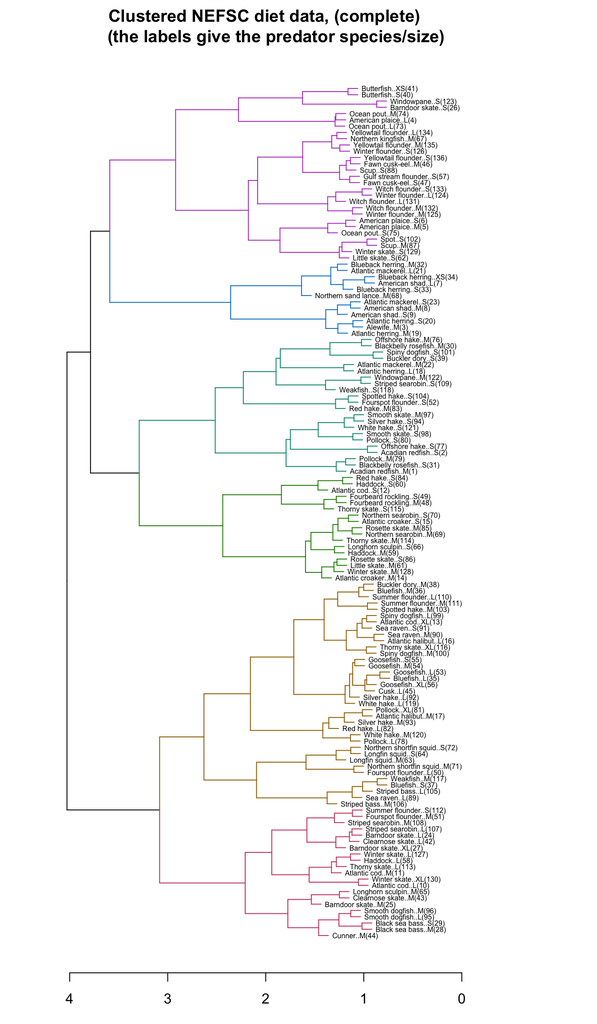

```r
dietoverlap <- read_csv(here("data-raw/tgmat.2022-02-15.csv"))

# follows example here https://cran.r-project.org/web/packages/dendextend/vignettes/Cluster_Analysis.html

library(dendextend)

d_dietoverlap <- dist(dietoverlap)

guilds <- hclust(d_dietoverlap)

#plot(guilds)

dend <- as.dendrogram(guilds)

dend <- rotate(dend, 1:136)

dend <- color_branches(dend, k=6) # Brian uses 6 categories

labels(dend) <- paste(as.character(names(dietoverlap[-1]))[order.dendrogram(dend)],
                           "(",labels(dend),")",
                           sep = "")

dend <- hang.dendrogram(dend,hang_height=0.1)

# reduce the size of the labels:
# dend <- assign_values_to_leaves_nodePar(dend, 0.5, "lab.cex")
dend <- set(dend, "labels_cex", 0.5)
# And plot:
par(mar = c(3,3,3,7))
plot(dend,
     main = "Clustered NEFSC diet data, (complete)
     (the labels give the predator species/size)",
     horiz =  TRUE,  nodePar = list(cex = .007))
```

```r
#legend("topleft", legend = iris_species, fill = rainbow_hcl(3))
```

We decided to use the cluster groups to eliminate pelagic species that would only rarely consume these prey. Therefore we will use species in 4 of the 6 clusters, but not use species in the planktivore cluster (blue above) or the piscivore cluster (gold above).

Therefore, the following is the NEFSC BTS predator/size list:

```r
pisc <- partition_leaves(dend)[[
  which_node(dend, c("Bluefish..S(37)", "Bluefish..M(36)", "Bluefish..L(35)"))
]]

piscdf <- data.frame("COMNAME" = toupper(str_remove(pisc, "\\..*")),
                             "SizeCat" = str_remove(str_extract(pisc, "\\..*[:upper:]+"), "\\.."))


plank <- partition_leaves(dend)[[
  which_node(dend, c("Atlantic herring..S(20)", "Atlantic mackerel..S(23)", "Blueback herring..XS(34)"))
]]

plankdf <- data.frame("COMNAME" = toupper(str_remove(plank, "\\..*")),
                             "SizeCat" = str_remove(str_extract(plank, "\\..*[:upper:]+"), "\\.."))

all <- partition_leaves(dend)[[
  which_node(dend, c("Barndoor skate..S(26)", "Bluefish..L(35)"))
]]

alldf <- data.frame("COMNAME" = toupper(str_remove(all, "\\..*")),
                             "SizeCat" = str_remove(str_extract(all, "\\..*[:upper:]+"), "\\.."))

sizedef <- readxl::read_excel(here::here("data-raw/Table3.xlsx"),
                              range = "B3:H55") |>  # table of NEFSC FH size categories from Brian
  dplyr::rename(XS = `Extra-Small`,
                S = "Small",
                M = "Medium",
                L = "Large",
                XL = `Extra-Large`,
                CommonName = `Common Name`,
                SpeciesName = `Species Name`) |>
  tidyr::pivot_longer(-c(1:2), names_to = "sizecat", values_to = "range") |>
  dplyr::filter(!range=="-") |>
  dplyr::mutate(COMNAME = toupper(CommonName))


# add missing by hand from word Table 1.docx
# (pollock was misspelled, fixed in spreadsheet)
# (removed "flounder" from Windowpane in spreadsheet)
# asked Brian for these; response:
# For these predators and most likely any others not listed in TM216,
# the default is S (<=20 cm), M (>20 and <=50 cm), and L (>50 cm).
# Northern kingfish M
# Buckler dory S
# Fourbeard rockling S
# Fourbeard rockling M
# Cunner M

extra <- data.frame(CommonName = c("Northern kingfish",
                                      "Buckler dory",
                                      "Fourbeard rockling",
                                      "Fourbeard rockling",
                                      "Cunner"),
                    sizecat = c("M",
                                "S",
                                "S",
                                "M",
                                "M"),
                    range = c("21-50",
                              "≤20",
                              "≤20",
                              "21-50",
                              "21-50"))  |>
  dplyr::mutate(COMNAME = toupper(CommonName))

sizedef <- bind_rows(sizedef, extra)

 # dplyr::mutate(COMNAME = toupper(`Common Name`),
 #               XS = readr::parse_number(`Extra-Small`),
 #               S = readr::parse_number(Small),
 #               M = readr::parse_number(Medium),
 #               L = readr::parse_number(Large),
 #               XL = readr::parse_number(`Extra-Large`))


# we'll call benthivores everything but piscivores and planktivores
benthivores <- alldf |>
  dplyr::anti_join(dplyr::bind_rows(piscdf, plankdf)) |>
  dplyr::left_join(sizedef, join_by(COMNAME == COMNAME, SizeCat == sizecat)) |>
  dplyr::left_join(ecodata::species_groupings, by = "COMNAME") |>
  dplyr::select(COMNAME, ITISSPP, SCINAME, SizeCat = SizeCat.x, SizeRange_cm = range) |>
  dplyr::distinct()

datatable(benthivores, rownames = FALSE,
          extensions = c("FixedColumns"),
          caption = "Predator list for benthos indices",
          options = list(pageLength = 90,
                         scrollX = TRUE,
                         fixedColumns = list(leftColumns = 1)))
```

| COMNAME | ITISSPP | SCINAME | SizeCat | SizeRange_cm |
| --- | --- | --- | --- | --- |
| CUNNER | 170481 | TAUTOGOLABRUS ADSPERSUS | M | 21-50 |
| BLACK SEA BASS | 167687 | CENTROPRISTIS STRIATA | M | 26-50 |
| BLACK SEA BASS | 167687 | CENTROPRISTIS STRIATA | S | ≤25 |
| SMOOTH DOGFISH | 160230 | MUSTELUS CANIS | L | &gt;80 |
| SMOOTH DOGFISH | 160230 | MUSTELUS CANIS | M | 36-80 |
| BARNDOOR SKATE | 564139 | DIPTURUS LAEVIS | M | 31-60 |
| CLEARNOSE SKATE | 160855 | RAJA EGLANTERIA | M | 31-60 |
| LONGHORN SCULPIN | 167320 | MYOXOCEPHALUS OCTODECEMSPINOSUS | M | 26-50 |
| ATLANTIC COD | 164712 | GADUS MORHUA | L | 51-80 |
| WINTER SKATE | 564145 | LEUCORAJA OCELLATA | XL | &gt;80 |

[output cut: 78 more lines]

```r
# no need to save this every time
#saveRDS(benthivores, here::here("data/benthivorelist.rds"))
```

## Which surveys?

Start with NEFSC, find out if MA and ME/NH surveys collect diet information, and add NEAMAP later once predator and prey lists are well established.

MA and ME/NH surveys do not collect diet information.

As of January 2024, predator and prey lists are established enough for a NEAMAP request. Just needed to add the size categories; almost there…

Add ITISSPP to prey lists where possible

```r
macrobenITIS <- macroben |>
  dplyr::select(PYNAM, PYCOMNAM, PYSPP) |>
  dplyr::left_join(ecodata::species_groupings, join_by(PYNAM == SCINAME)) |>
  dplyr::select(PYNAM, PYCOMNAM, COMNAME, PYSPP, ITISSPP)

megabenITIS <- megaben |>
  dplyr::select(PYNAM, PYCOMNAM, PYSPP) |>
  dplyr::left_join(ecodata::species_groupings, join_by(PYNAM == SCINAME)) |>
  dplyr::select(PYNAM, PYCOMNAM, COMNAME, PYSPP, ITISSPP)

saveRDS(macrobenITIS, here::here("data/macrobenthosprey.rds"))
saveRDS(megabenITIS, here::here("data/megabenthosprey.rds"))
```

NEAMAP survey results received May 2024 using the above prey lists.

Jim Gartland provided a lookup table of NEFSC to NEAMAP prey codes! Add to ecodata for future use.

For this modify the [data generation script in the forageindex repo](https://github.com/NOAA-EDAB/forageindex/blob/main/fhdat/VASTforage_ProcessInputDat.R).

All data have been combined in the new script VASTbenthos_ProcessInputDat.R:

```r
# Streamlined version of CreateVASTInputs.Rmd for operational updates to forage index indicators
# Modified for benthos index
# May 2024
#   This one is updating with 2022 NEFSC and NEAMAP data and OISST
#   To be used in the 2024 State of the Ecosystem report

library(tidyverse)
library(here)
library(dendextend)

# Load NEFSC stomach data received from Brian Smith

# object is called `allfh`
load(url("https://github.com/NOAA-EDAB/forageindex/raw/main/fhdat/allfh.Rdata"))

#object is called allfh21
load(url("https://github.com/NOAA-EDAB/forageindex/raw/main/fhdat/allfh21.RData"))

#object is called allfh22
load(url("https://github.com/NOAA-EDAB/forageindex/raw/main/fhdat/allfh22.RData"))

# bind all NEFSC stomach datasets
allfh <- allfh %>%
  dplyr::bind_rows(allfh21) |>
  dplyr::bind_rows(allfh22)

# can we deload the 21 and 22 datasets?
rm("allfh21", "allfh22")

###############################################################################
# read predator similarity info to generate predator list
# Input NEFSC food habits overlap matrix:

dietoverlap <- read_csv(here("data-raw/tgmat.2022-02-15.csv"))

# use dendextend functions to get list
d_dietoverlap <- dist(dietoverlap)

guilds <- hclust(d_dietoverlap)

#plot(guilds)

dend <- as.dendrogram(guilds)

dend <- rotate(dend, 1:136)

dend <- color_branches(dend, k=6) # Brian uses 6 categories

labels(dend) <- paste(as.character(names(dietoverlap[-1]))[order.dendrogram(dend)],
                      "(",labels(dend),")",
                      sep = "")

dend <- hang.dendrogram(dend,hang_height=0.1)

pisc <- partition_leaves(dend)[[
  which_node(dend, c("Bluefish..S(37)", "Bluefish..M(36)", "Bluefish..L(35)"))
]]

piscdf <- data.frame("COMNAME" = toupper(str_remove(pisc, "\\..*")),
                     "SizeCat" = str_remove(str_extract(pisc, "\\..*[:upper:]+"), "\\.."))


plank <- partition_leaves(dend)[[
  which_node(dend, c("Atlantic herring..S(20)", "Atlantic mackerel..S(23)", "Blueback herring..XS(34)"))
]]

plankdf <- data.frame("COMNAME" = toupper(str_remove(plank, "\\..*")),
                      "SizeCat" = str_remove(str_extract(plank, "\\..*[:upper:]+"), "\\.."))

all <- partition_leaves(dend)[[
  which_node(dend, c("Barndoor skate..S(26)", "Bluefish..L(35)"))
]]

alldf <- data.frame("COMNAME" = toupper(str_remove(all, "\\..*")),
                    "SizeCat" = str_remove(str_extract(all, "\\..*[:upper:]+"), "\\.."))

sizedef <- readxl::read_excel(here::here("data-raw/Table3.xlsx"),
                              range = "B3:H55") |>  # table of NEFSC FH size categories from Brian
  dplyr::rename(XS = `Extra-Small`,
                S = "Small",
                M = "Medium",
                L = "Large",
                XL = `Extra-Large`,
                CommonName = `Common Name`,
                SpeciesName = `Species Name`) |>
  tidyr::pivot_longer(-c(1:2), names_to = "sizecat", values_to = "range") |>
  dplyr::filter(!range=="-") |>
  dplyr::mutate(COMNAME = toupper(CommonName))


# add missing by hand from word Table 1.docx
# (pollock was misspelled, fixed in spreadsheet)
# (removed "flounder" from Windowpane in spreadsheet)
# asked Brian for these; response:
# For these predators and most likely any others not listed in TM216,
# the default is S (<=20 cm), M (>20 and <=50 cm), and L (>50 cm).
# Northern kingfish M
# Buckler dory S
# Fourbeard rockling S
# Fourbeard rockling M
# Cunner M

extra <- data.frame(CommonName = c("Northern kingfish",
                                   "Buckler dory",
                                   "Fourbeard rockling",
                                   "Fourbeard rockling",
                                   "Cunner"),
                    sizecat = c("M",
                                "S",
                                "S",
                                "M",
                                "M"),
                    range = c("21-50",
                              "≤20",
                              "≤20",
                              "21-50",
                              "21-50"))  |>
  dplyr::mutate(COMNAME = toupper(CommonName))

sizedef <- bind_rows(sizedef, extra)

# dplyr::mutate(COMNAME = toupper(`Common Name`),
#               XS = readr::parse_number(`Extra-Small`),
#               S = readr::parse_number(Small),
#               M = readr::parse_number(Medium),
#               L = readr::parse_number(Large),
#               XL = readr::parse_number(`Extra-Large`))


# we'll call benthivores everything but piscivores and planktivores
benthivores <- alldf |>
  dplyr::anti_join(dplyr::bind_rows(piscdf, plankdf)) |>
  dplyr::left_join(sizedef, join_by(COMNAME == COMNAME, SizeCat == sizecat)) |>
  dplyr::left_join(ecodata::species_groupings, by = "COMNAME") |>
  dplyr::select(COMNAME, ITISSPP, SCINAME, SizeCat = SizeCat.x, SizeRange_cm = range) |>
  dplyr::distinct()

fh.nefsc.benthivore.complete <- allfh %>%
  #filter(pynam != "EMPTY") %>%
  left_join(benthivores, by = c("pdcomnam" = "COMNAME",
                                   "sizecat" = "SizeCat"))


##############################################################################
# Get prey list from Rpath megabenthos and macrobenthos categories

# Rpath prey list, object is called prey
load(here("data/prey.RData")) #original mappings from June 2023

# make adjustments to list based on modeling group discussions
addtomacro <- prey |>
  dplyr::filter(RPATH == "Megabenthos") |>
  dplyr::filter(PYNAM %in% c("ALBUNEA PARETII", "EMERITA TALPOIDA", "RANILIA MURICATA", "HIPPIDAE"))

megaben <- prey |>
  dplyr::filter(RPATH == "Megabenthos") |>
  dplyr::filter(!PYNAM %in% c("ALBUNEA PARETII", "EMERITA TALPOIDA", "RANILIA MURICATA", "HIPPIDAE"))

macroben <- prey |>
  dplyr::filter(RPATH == "Macrobenthos") |>
  dplyr::filter(!PYNAM %in% c("PECTINIDAE", "PECTINIDAE SHELL", "PECTINIDAE VISCERA")) |>
  dplyr::bind_rows(addtomacro)

macrobenfh <- allfh %>%
  dplyr::left_join(macroben %>%
                     dplyr::select(PYNAM, RPATH) %>%
                     setNames(., tolower(names(.)))) %>%
  dplyr::filter(!is.na(rpath))
```

```r
megabenfh <- allfh %>%
  dplyr::left_join(megaben %>%
                     dplyr::select(PYNAM, RPATH) %>%
                     setNames(., tolower(names(.)))) %>%
  dplyr::filter(!is.na(rpath))

macrobenITIS <- macroben |>
  dplyr::select(PYNAM, PYCOMNAM, PYSPP) |>
  dplyr::left_join(ecodata::species_groupings, join_by(PYNAM == SCINAME)) |>
  dplyr::select(PYNAM, PYCOMNAM, COMNAME, PYSPP, ITISSPP) |>
  as.data.frame()

megabenITIS <- megaben |>
  dplyr::select(PYNAM, PYCOMNAM, PYSPP) |>
  dplyr::left_join(ecodata::species_groupings, join_by(PYNAM == SCINAME)) |>
  dplyr::select(PYNAM, PYCOMNAM, COMNAME, PYSPP, ITISSPP) |>
  as.data.frame()


fh.nefsc.benthivore.complete.macrobenthos <- fh.nefsc.benthivore.complete %>%
  mutate(macrobenthos = case_when(pynam %in% macrobenITIS$PYNAM ~ "macroben",
                              TRUE ~ "othprey"))

fh.nefsc.benthivore.complete.megabenthos <- fh.nefsc.benthivore.complete %>%
  mutate(megabenthos = case_when(pynam %in% megabenITIS$PYNAM ~ "megaben",
                                  TRUE ~ "othprey"))


###############################################################################
# Make the NEFSC macrobenthos dataset aggregating prey based on prey list
# lets keep the month and day info for the merge with modeled bottom temperature!

macrobenall_stn <- fh.nefsc.benthivore.complete.macrobenthos %>%
  #create id linking cruise6_station
  #create season_ng spring and fall Spring=Jan-May, Fall=June-Dec
  mutate(id = paste0(cruise6, "_", station),
         year = as.numeric(year),
         month = as.numeric(month),
         day = as.numeric(day),
         season_ng = case_when(month <= 6 ~ "SPRING",
                               month >= 7 ~ "FALL",
                               TRUE ~ as.character(NA))
  ) %>%
  dplyr::select(year, month, day, season_ng, id, stratum,
                pynam, pyamtw, pywgti, pyvoli, macrobenthos,
                pdcomnam, pdid, pdlen, pdsvol, pdswgt,
                beglat, beglon, declat, declon,
                bottemp, surftemp, setdepth) %>%
  group_by(id) %>%
  #mean macrobenthos g per stomach per tow: sum all macrobenthos g/n stomachs in tow
  mutate(macrobenpywt = case_when(macrobenthos == "macroben" ~ pyamtw,
                              TRUE ~ 0.0),
         macrobenpynam = case_when(macrobenthos == "macroben" ~ pynam,
                               TRUE ~ NA_character_))

# Optional: save at prey disaggregated stage for paper
#saveRDS(macrobenall_stn, here("fhdata/macrobenall_stn.rds"))

# Now get station data in one line
stndat <- macrobenall_stn %>%
  dplyr::select(year, month, day, season_ng, id,
                beglat, beglon, declat, declon,
                bottemp, surftemp, setdepth) %>%
  distinct()

#benthivore stomachs in tow count pdid for each pred and sum
benthivorestom <- macrobenall_stn %>%
  group_by(id, pdcomnam) %>%
  summarise(nstompd = n_distinct(pdid)) %>%
  group_by(id) %>%
  summarise(nstomtot = sum(nstompd))

#mean and var pred length per tow
benthivorelen <-  macrobenall_stn %>%
  summarise(meanbenthivorelen = mean(pdlen),
            varbenthivorelen = var(pdlen))

# Aggregated prey at station level with predator covariates
macrobenagg_stn <- macrobenall_stn %>%
  summarise(summacrobenpywt = sum(macrobenpywt),
            nmacrobenpysp = n_distinct(macrobenpynam, na.rm = T),
            npreysp = n_distinct(pynam),
            nbenthivoresp = n_distinct(pdcomnam)) %>%
  left_join(benthivorestom) %>%
  mutate(meanmacrobenpywt = summacrobenpywt/nstomtot) %>%
  left_join(benthivorelen) %>%
  left_join(stndat)

# save at same stage as before, writing over old file
#saveRDS(bluepyagg_stn, here("fhdat/bluepyagg_stn.rds"))

# current dataset, fix declon, add vessel, rename NEFSC
#nefsc_bluepyagg_stn <- readRDS(here("fhdat/bluepyagg_stn.rds")) %>%
nefsc_macrobenagg_stn <- macrobenagg_stn %>%
  mutate(declon = -declon,
         vessel = case_when(year<2009 ~ "AL",
                            year>=2009 ~ "HB",
                            TRUE ~ as.character(NA)))

##############################################################################
# Add NEAMAP macrobenthos to make full aggregated stomach dataset

# Read in NEAMAP updated input from Jim Gartland, reformat with same names
neamap_macrobenthos_stn <- read_csv(here("fhdata/NEAMAP_Mean Stomach Weights_Macrobenthos prey_wWQ.csv")) %>%
  mutate(vessel = "NEAMAP") %>%
  rename(id = station,
         summacrobenpywt = summacpreywt,
         nmacrobenpysp = nmacpreysp,
         #npreysp = ,
         nbenthivoresp = nbenthivorespp,
         nstomtot = nstomtot,
         meanmacrobenpywt = meanmacpreywt,
         meanbenthivorelen = meanbenthivorelen.simple,
         #varbenthivorelen = ,
         season_ng = season,
         declat  = lat,
         declon = lon,
         bottemp = bWT,
         surftemp = SST, # new NEAMAP already contains SST
         setdepth = depthm)

# Add NEAMAP month and day information
NEAMAPstationSST <- read.csv("https://raw.githubusercontent.com/NOAA-EDAB/forageindex/main/fhdat/NEAMAP%20SST_2007_2022.csv")

NEAMAPstations <- NEAMAPstationSST %>%
  dplyr::mutate(id = station,
                year = as.numeric(year),
                month = as.numeric(month),
                day = as.numeric(day)
                ) %>%
  dplyr::select(id, year, month, day) |>
  dplyr::distinct()

neamap_macrobenthos_stn <- dplyr::left_join(neamap_macrobenthos_stn, NEAMAPstations)


# combine NEAMAP and NEFSC
macrobenagg_stn_all <-  nefsc_macrobenagg_stn %>%
  bind_rows(neamap_macrobenthos_stn)

# Save before SST integration step
saveRDS(macrobenagg_stn_all, here("fhdata/macrobenagg_stn_all.rds"))

###############################################################################
# Now make the megabenthos dataset using the same steps, NEFSC then NEAMAP
# These will be SEPARATE UNIVARIATE MODELS to start so making them separate

###############################################################################
# Make the NEFSC macrobenthos dataset aggregating prey based on prey list
```

```r
megabenall_stn <- fh.nefsc.benthivore.complete.megabenthos %>%
  #create id linking cruise6_station
  #create season_ng spring and fall Spring=Jan-May, Fall=June-Dec
  mutate(id = paste0(cruise6, "_", station),
         year = as.numeric(year),
         month = as.numeric(month),
         day = as.numeric(day),
         season_ng = case_when(month <= 6 ~ "SPRING",
                               month >= 7 ~ "FALL",
                               TRUE ~ as.character(NA))
  ) %>%
  dplyr::select(year, month, day, season_ng, id, stratum,
                pynam, pyamtw, pywgti, pyvoli, megabenthos,
                pdcomnam, pdid, pdlen, pdsvol, pdswgt,
                beglat, beglon, declat, declon,
                bottemp, surftemp, setdepth) %>%
  group_by(id) %>%
  #mean megabenthos g per stomach per tow: sum all megabenthos g/n stomachs in tow
  mutate(megabenpywt = case_when(megabenthos == "megaben" ~ pyamtw,
                                  TRUE ~ 0.0),
         megabenpynam = case_when(megabenthos == "megaben" ~ pynam,
                                   TRUE ~ NA_character_))

# Optional: save at prey disaggregated stage for paper
#saveRDS(megabenall_stn, here("fhdata/megabenall_stn.rds"))

# Now get station data in one line
stndat <- megabenall_stn %>%
  dplyr::select(year, month, day, season_ng, id,
                beglat, beglon, declat, declon,
                bottemp, surftemp, setdepth) %>%
  distinct()

#benthivore stomachs in tow count pdid for each pred and sum
benthivorestom <- megabenall_stn %>%
  group_by(id, pdcomnam) %>%
  summarise(nstompd = n_distinct(pdid)) %>%
  group_by(id) %>%
  summarise(nstomtot = sum(nstompd))

#mean and var pred length per tow
benthivorelen <-  megabenall_stn %>%
  summarise(meanbenthivorelen = mean(pdlen),
            varbenthivorelen = var(pdlen))

# Aggregated prey at station level with predator covariates
megabenagg_stn <- megabenall_stn %>%
  summarise(summegabenpywt = sum(megabenpywt),
            nmegabenpysp = n_distinct(megabenpynam, na.rm = T),
            npreysp = n_distinct(pynam),
            nbenthivoresp = n_distinct(pdcomnam)) %>%
  left_join(benthivorestom) %>%
  mutate(meanmegabenpywt = summegabenpywt/nstomtot) %>%
  left_join(benthivorelen) %>%
  left_join(stndat)

# save at same stage as before, writing over old file
#saveRDS(bluepyagg_stn, here("fhdat/bluepyagg_stn.rds"))

# current dataset, fix declon, add vessel, rename NEFSC
#nefsc_bluepyagg_stn <- readRDS(here("fhdat/bluepyagg_stn.rds")) %>%
nefsc_megabenagg_stn <- megabenagg_stn %>%
  mutate(declon = -declon,
         vessel = case_when(year<2009 ~ "AL",
                            year>=2009 ~ "HB",
                            TRUE ~ as.character(NA)))

##############################################################################
# Add NEAMAP megabenthos to make full aggregated stomach dataset

# Read in NEAMAP updated input from Jim Gartland, reformat with same names
neamap_megabenthos_stn <- read_csv(here("fhdata/NEAMAP_Mean Stomach Weights_Megabenthos prey_wWQ.csv")) %>%
  mutate(vessel = "NEAMAP") %>%
  rename(id = station,
         summegabenpywt = summgbpreywt,
         nmegabenpysp = nmgbpreysp,
         #npreysp = ,
         nbenthivoresp = nbenthivorespp,
         nstomtot = nstomtot,
         meanmegabenpywt = meanmgbpreywt,
         meanbenthivorelen = meanbenthivorelen.simple,
         #varbenthivorelen = ,
         season_ng = season,
         declat  = lat,
         declon = lon,
         bottemp = bWT,
         surftemp = SST, # new NEAMAP already contains SST
         setdepth = depthm)

# Add NEAMAP month and day information
# done above but uncomment if running separately
# NEAMAPstationSST <- read.csv("https://raw.githubusercontent.com/NOAA-EDAB/forageindex/main/fhdat/NEAMAP%20SST_2007_2022.csv")
#
# NEAMAPstations <- NEAMAPstationSST %>%
#   dplyr::mutate(id = station,
#                 year = as.numeric(year),
#                 month = as.numeric(month),
#                 day = as.numeric(day)
#   ) %>%
#   dplyr::select(id, year, month, day) |>
#   dplyr::distinct()

neamap_megabenthos_stn <- dplyr::left_join(neamap_megabenthos_stn, NEAMAPstations)

# combine NEAMAP and NEFSC
megabenagg_stn_all <-  nefsc_megabenagg_stn %>%
  bind_rows(neamap_megabenthos_stn)

# Save before SST integration step
saveRDS(megabenagg_stn_all, here("fhdata/megabenagg_stn_all.rds"))

###############################################################################

# STOP HERE for initial models, explore without modeled temp covariates

# ###############################################################################

# functions that read in bottom temperature nc files are in
# https://noaa-edab.github.io/benthosindex/BottomTempFill.html
# assuming that those files exist and are in the folder data-raw/bottomtemp/bt_data
# the following will merge them with the data above

#######################################################################
# Macrobenthos

macrobenagg_stn_all <- readRDS(here("fhdata/macrobenagg_stn_all.rds"))

stations <- macrobenagg_stn_all %>%
  #dplyr::mutate(day = str_pad(day, 2, pad='0'),
  #              month = str_pad(month, 2, pad='0'),
  #              yrmody = as.numeric(paste0(year, month, day))) %>%
  # consider this instead, may not need to pad strings? already date fields in the bt data
  dplyr::mutate(date = as.Date(paste0(year,"-", month,"-", day)), numdate = as.numeric(date)) |>
  dplyr::select(id, declon, declat, year, numdate) %>%
  na.omit() %>%
  sf::st_as_sf(coords=c("declon","declat"), crs=4326, remove=FALSE)



#list of SST dataframes
BTdfs <- list.files(here("data-raw/bottomtemp/bt_data/"), pattern = "*.rds")

dietstn_mod_bt <- tibble()


for(df in BTdfs){
  btdf <- readRDS(paste0(here("data-raw/bottomtemp/bt_data/", df)))

  if(unique(btdf$year) %in% unique(stations$year)){
    # keep only bluefish dates in SST year
    stationsyr <- stations %>%
      filter(year == unique(btdf$year))

    # keep only modeled bt days in survey dataset
    btdf_survdays <- btdf %>%
      dplyr::mutate(numdate = as.numeric(date))%>%
      dplyr::filter(numdate %in% unique(stationsyr$numdate)) %>%
      dplyr::mutate(year = as.numeric(year),
                    month = as.numeric(month),
                    day = as.numeric(day),
                    declon = longitude,
                    declat = latitude) %>%
      dplyr::select(-longitude, -latitude) %>%
      sf::st_as_sf(coords=c("declon","declat"), crs=4326, remove=FALSE)
```

```r
    # now join by nearest neighbor and date

    #https://stackoverflow.com/questions/71959927/spatial-join-two-data-frames-by-nearest-feature-and-date-in-r

    yrdietmodBT <- do.call('rbind', lapply(split(stationsyr, 1:nrow(stationsyr)), function(x) {
      sf::st_join(x, btdf_survdays[btdf_survdays$numdate == unique(x$ numdate),],
                  #join = st_nearest_feature
                  join = st_nn, k = 1, progress = FALSE
      )
    }))

    #   #datatable solution--works but doesnt seem faster?
    #    df1 <- data.table(stationsyr)
    #
    #  .nearest_samedate <- function(x) {
    #    st_join(st_as_sf(x), sstdf_survdays[sstdf_survdays$yrmody == unique(x$yrmody),], join = st_nearest_feature)
    #  }
    # #
    #  yrdietOISST <- df1[, .nearest_samedate(.SD), by = list(1:nrow(df1))]

    dietstn_mod_bt <- rbind(dietstn_mod_bt,  yrdietmodBT)
  }
}

#saveRDS(dietstn_OISST, here("data-raw/dietstn_OISST.rds"))

# Now join with OISST dataset

#bluepyagg_stn_all <- readRDS(here("fhdat/bluepyagg_stn_all.rds"))
#dietstn_OISST <- readRDS(here("data-raw/dietstn_OISST.rds"))


dietstn_mod_bt_merge <- dietstn_mod_bt %>%
  dplyr::rename(declon = declon.x,
                declat = declat.x,
                year = year.x) %>%
  dplyr::select(id, mod_bt) %>%
  sf::st_drop_geometry()

macrobenagg_stn_all_modBT <- left_join(macrobenagg_stn_all, dietstn_mod_bt_merge)

saveRDS(macrobenagg_stn_all_modBT, here::here("fhdata/macrobenagg_stn_all_modBT.rds"))


#######################################################################
# Megabenthos

megabenagg_stn_all <- readRDS(here("fhdata/megabenagg_stn_all.rds"))

stations <- megabenagg_stn_all %>%
  #dplyr::mutate(day = str_pad(day, 2, pad='0'),
  #              month = str_pad(month, 2, pad='0'),
  #              yrmody = as.numeric(paste0(year, month, day))) %>%
  # consider this instead, may not need to pad strings? already date fields in the bt data
  dplyr::mutate(date = as.Date(paste0(year,"-", month,"-", day)), numdate = as.numeric(date)) |>
  dplyr::select(id, declon, declat, year, numdate) %>%
  na.omit() %>%
  sf::st_as_sf(coords=c("declon","declat"), crs=4326, remove=FALSE)



#list of SST dataframes
BTdfs <- list.files(here("data-raw/bottomtemp/bt_data/"), pattern = "*.rds")

dietstn_mod_bt <- tibble()


for(df in BTdfs){
  btdf <- readRDS(paste0(here("data-raw/bottomtemp/bt_data/", df)))

  if(unique(btdf$year) %in% unique(stations$year)){
    # keep only bluefish dates in SST year
    stationsyr <- stations %>%
      filter(year == unique(btdf$year))

    # keep only modeled bt days in survey dataset
    btdf_survdays <- btdf %>%
      dplyr::mutate(numdate = as.numeric(date))%>%
      dplyr::filter(numdate %in% unique(stationsyr$numdate)) %>%
      dplyr::mutate(year = as.numeric(year),
                    month = as.numeric(month),
                    day = as.numeric(day),
                    declon = longitude,
                    declat = latitude) %>%
      dplyr::select(-longitude, -latitude) %>%
      sf::st_as_sf(coords=c("declon","declat"), crs=4326, remove=FALSE)

    # now join by nearest neighbor and date

    #https://stackoverflow.com/questions/71959927/spatial-join-two-data-frames-by-nearest-feature-and-date-in-r

    yrdietmodBT <- do.call('rbind', lapply(split(stationsyr, 1:nrow(stationsyr)), function(x) {
      sf::st_join(x, btdf_survdays[btdf_survdays$numdate == unique(x$ numdate),],
                  #join = st_nearest_feature
                  join = st_nn, k = 1, progress = FALSE
      )
    }))

    #   #datatable solution--works but doesnt seem faster?
    #    df1 <- data.table(stationsyr)
    #
    #  .nearest_samedate <- function(x) {
    #    st_join(st_as_sf(x), sstdf_survdays[sstdf_survdays$yrmody == unique(x$yrmody),], join = st_nearest_feature)
    #  }
    # #
    #  yrdietOISST <- df1[, .nearest_samedate(.SD), by = list(1:nrow(df1))]

    dietstn_mod_bt <- rbind(dietstn_mod_bt,  yrdietmodBT)
  }
}

#saveRDS(dietstn_OISST, here("data-raw/dietstn_OISST.rds"))

# Now join with OISST dataset

#bluepyagg_stn_all <- readRDS(here("fhdat/bluepyagg_stn_all.rds"))
#dietstn_OISST <- readRDS(here("data-raw/dietstn_OISST.rds"))


dietstn_mod_bt_merge <- dietstn_mod_bt %>%
  dplyr::rename(declon = declon.x,
                declat = declat.x,
                year = year.x) %>%
  dplyr::select(id, mod_bt) %>%
  sf::st_drop_geometry()

megabenagg_stn_all_modBT <- left_join(megabenagg_stn_all, dietstn_mod_bt_merge)

saveRDS(megabenagg_stn_all_modBT, here::here("fhdata/megabenagg_stn_all_modBT.rds"))
```

## Spatial scale

Suggestion: use entire VAST northwest-atlantic grid for estimation and split out GOM and GB as was done for the forage fish index.

## Covariates

Suggestion: start with mean predator size at a station, number of predator species at a station, and bottom water temperature. Is there anything else we would want for benthic organisms? Reviewers suggested depth for the forage fish index, but it did not converge and may be more appropriate as a habitat covariate.

### Fill missing physical data?

When I looked at bottom temperature data in the NEFSC survey, we had as many missing values as for surface temperature, so it is likely we will want to fill these with other data sources to avoid losing information. Hubert DuPontavice provided his reconstruction of bottom temperatures based on GLORYS and ROMS outputs for the NEUS. The full 1.1 GB dataset is stored locally in data-raw/bottomtemp and the identical source file is [here on google drive](https://drive.google.com/file/d/11HanY5Tzu--77HevCV5gRdNvaAvuYVYU/view?usp=share_link).

Bottom temp has been filled in, see documentation and comparisons [here](https://noaa-edab.github.io/benthosindex/BottomTempFill.html).

# Modeling

## VAST model setup

Univariate or multivariate? First lets try separate univariate models for each of the prey groups, one model for macrobenthos and one for megabenthos. Then we can get fancier trying to look at a multivariate model?

Do we want to separate seasons or try an annual model? I guess it depends on how the Rpaths are set up.

DECISION: Fall is how the GOM is parameterized so start with that. Doing spring too.

These scripts tested fall and spring models, no covariates but estimating full spatial and spatio-temporal RE and anistotropy (current versions run with covariates and bias correction, linked below).

https://github.com/NOAA-EDAB/benthosindex/blob/fc878aa03f4b744dc87407d4348fce8abdeb82d8/VASTscripts/VASTunivariate_macrobenthos_allsurvs.R

https://github.com/NOAA-EDAB/benthosindex/blob/fc878aa03f4b744dc87407d4348fce8abdeb82d8/VASTscripts/VASTunivariate_megabenthos_allsurvs.R

## VAST model selection

Lets do the same model selection as previously. Two stages, first looking at spatial, spatio-temporal random effects and the second looking at covariates. For completeness, do selection for both models.

Model selection script is https://github.com/NOAA-EDAB/benthosindex/blob/main/VASTscripts/VASTunivariate_benthos_modselection.R

### Stage 1 results

```r
# from each output folder in pyindex,
outdir <- here::here("pyindex_modsel1")
moddirs <- list.dirs(outdir)
moddirs <- moddirs[-1]
# keep folder name
modnames <- list.dirs(outdir, full.names = FALSE)


# function to apply extracting info
getmodinfo <- function(d.name){
  # read settings
  modpath <- stringr::str_split(d.name, "/", simplify = TRUE)
  modname <- modpath[length(modpath)]

  settings <- read.table(file.path(d.name, "settings.txt"), comment.char = "",
    fill = TRUE, header = FALSE)

  n_x <- as.numeric(as.character(settings[(which(settings[,1]=="$n_x")+1),2]))
  grid_size_km <- as.numeric(as.character(settings[(which(settings[,1]=="$grid_size_km")+1),2]))
  max_cells <- as.numeric(as.character(settings[(which(settings[,1]=="$max_cells")+1),2]))
  use_anisotropy <- as.character(settings[(which(settings[,1]=="$use_anisotropy")+1),2])
  fine_scale <- as.character(settings[(which(settings[,1]=="$fine_scale")+1),2])
  bias.correct <- as.character(settings[(which(settings[,1]=="$bias.correct")+1),2])

  #FieldConfig
  if(settings[(which(settings[,1]=="$FieldConfig")+1),1]=="Component_1"){
    omega1 <- as.character(settings[(which(settings[,1]=="$FieldConfig")+2),2])
    omega2 <- as.character(settings[(which(settings[,1]=="$FieldConfig")+3),1])
    epsilon1 <- as.character(settings[(which(settings[,1]=="$FieldConfig")+4),2])
    epsilon2 <- as.character(settings[(which(settings[,1]=="$FieldConfig")+5),1])
    beta1 <- as.character(settings[(which(settings[,1]=="$FieldConfig")+6),2])
    beta2 <- as.character(settings[(which(settings[,1]=="$FieldConfig")+7),1])
  }

  if(settings[(which(settings[,1]=="$FieldConfig")+1),1]=="Omega1"){
    omega1 <- as.character(settings[(which(settings[,1]=="$FieldConfig")+3),1])
    omega2 <- as.character(settings[(which(settings[,1]=="$FieldConfig")+4),1])
    epsilon1 <- as.character(settings[(which(settings[,1]=="$FieldConfig")+3),2])
    epsilon2 <- as.character(settings[(which(settings[,1]=="$FieldConfig")+4),2])
    beta1 <- "IID"
    beta2 <- "IID"
  }


  #RhoConfig
  rho_beta1 <- as.numeric(as.character(settings[(which(settings[,1]=="$RhoConfig")+3),1]))
  rho_beta2 <- as.numeric(as.character(settings[(which(settings[,1]=="$RhoConfig")+3),2]))
  rho_epsilon1 <- as.numeric(as.character(settings[(which(settings[,1]=="$RhoConfig")+4),1]))
  rho_epsilon2 <- as.numeric(as.character(settings[(which(settings[,1]=="$RhoConfig")+4),2]))

  # read parameter estimates, object is called parameter_Estimates
  if(file.exists(file.path(d.name, "parameter_estimates.RData"))) {
    load(file.path(d.name, "parameter_estimates.RData"))

    AIC <- parameter_estimates$AIC[1]
    converged <- parameter_estimates$Convergence_check[1]
    fixedcoeff <- unname(parameter_estimates$number_of_coefficients[2])
    randomcoeff <- unname(parameter_estimates$number_of_coefficients[3])

  }else if(file.exists(file.path(d.name, "parameter_estimates.txt"))){

    reptext <- readLines(file.path(d.name, "parameter_estimates.txt"))

    AIC <- as.double(reptext[grep(reptext, pattern = "AIC")+1])
    converged <- reptext[grep(reptext, pattern = "Convergence_check")+1]
    fixedcoeff <- as.integer(stringr::str_split(reptext[grep(reptext, pattern = "number_of_coefficients")+2],
                                     boundary("word"))[[1]][2])
    randomcoeff <- as.integer(stringr::str_split(reptext[grep(reptext, pattern = "number_of_coefficients")+2],
                                     boundary("word"))[[1]][3])

  }else{

    AIC <- NA_real_
    converged <- NA_character_
    fixedcoeff <- NA_integer_
    randomcoeff <- NA_integer_
  }

  #index <- read.csv(file.path(d.name, "Index.csv"))


  # return model attributes as a dataframe
  out <- data.frame(modname = modname,
                    n_x = n_x,
                    grid_size_km = grid_size_km,
                    max_cells = max_cells,
                    use_anisotropy = use_anisotropy,
                    fine_scale =  fine_scale,
                    bias.correct = bias.correct,
                    omega1 = omega1,
                    omega2 = omega2,
                    epsilon1 = epsilon1,
                    epsilon2 = epsilon2,
                    beta1 = beta1,
                    beta2 = beta2,
                    rho_epsilon1 = rho_epsilon1,
                    rho_epsilon2 = rho_epsilon2,
                    rho_beta1 = rho_beta1,
                    rho_beta2 = rho_beta2,
                    AIC = AIC,
                    converged = converged,
                    fixedcoeff = fixedcoeff,
                    randomcoeff = randomcoeff#,
                    #index = index
  )

    return(out)

}


modcompare <- purrr::map_dfr(moddirs, getmodinfo)
```

Model selection 1 (spatial, spatio-temporal effects, no covariates) options (following @ng_predator_2021) and naming: * All models set Use_REML = TRUE in fit_model specifications.  
* Modeled effects, model name suffix, and VAST settings by model:

1. “_alleffectson” = Spatial and spatio-temporal random effects plus anisotropy in both linear predictors; FieldConfig default (all IID)
2. “_noaniso” = Spatial and spatio-temporal random effects in both linear predictors with anisotopy turned off; FieldConfig default (all IID) and `use_anisotopy = FALSE`
3. “_noomeps2” = Spatial and spatio-temporal random effects plus anisotropy only in linear predictor 1; FieldConfig = 0 for Omega2, Epsilon2
4. “_noomeps2_noaniso” = Spatial and spatio-temporal random effects only in linear predictor 1 with anisotopy turned off; FieldConfig = 0 for Omega2, Epsilon2 and `use_anisotopy = FALSE`
5. “_noomeps2_noeps1” = Spatial random effects plus anisotropy only in linear predictor 1; FieldConfig = 0 for Omega2, Epsilon2, Epsilon1
6. “_noomeps2_noeps1_noaniso” = Spatial random effects only in linear predictor 1 with anisotopy turned off; FieldConfig = 0 for Omega2, Epsilon2, Epsilon1 and `use_anisotopy = FALSE`
7. “_noomeps12” = Anisotropy, but no spatial or spatio-temporal random effects in either linear predictor; FieldConfig = 0 for both Omega, Epsilon
8. “_noomeps12_noaniso” = No spatial or spatio-temporal random effects in either linear predictor; FieldConfig = 0 for both Omega, Epsilon and `use_anisotopy = FALSE`

```r
modselect <- modcompare %>%
  dplyr::mutate(season = case_when(str_detect(modname, "_fall_") ~ "Fall",
                            str_detect(modname, "spring") ~ "Spring",
                            str_detect(modname, "_all_") ~ "Annual",
                            TRUE ~ as.character(NA))) %>%
  dplyr::mutate(converged2 = case_when(str_detect(converged, "no evidence") ~ "likely",
                                str_detect(converged, "is likely not") ~ "unlikely",
                                TRUE ~ as.character(NA))) %>%
  dplyr::mutate(bengroup = case_when(str_detect(modname, "macroben") ~ "macrobenthos",
                                str_detect(modname, "megaben") ~ "megabenthos",
                                TRUE ~ as.character(NA))) %>%
  #dplyr::mutate(modname = str_extract(modname, '(?<=allagg_).*')) |>
  dplyr::group_by(bengroup, season) %>%
  dplyr::mutate(deltaAIC = AIC-min(AIC)) %>%
  dplyr::select(modname, season, deltaAIC, fixedcoeff,
         randomcoeff, use_anisotropy,
         omega1, omega2, epsilon1, epsilon2,
         beta1, beta2, AIC, converged2) %>%
  dplyr::arrange(season, AIC)

# DT::datatable(modselect, rownames = FALSE,
#               options= list(pageLength = 25, scrollX = TRUE),
#               caption = "Comparison of delta AIC values using Restricted Maxiumum Likelihood (REML) for alternative fixed and random effects model structures. See text for model descriptions.")

flextable::flextable(modselect %>%
                       dplyr::select(-c(use_anisotropy,
         omega1, omega2, epsilon1, epsilon2,
         beta1, beta2))) %>%
  flextable::set_header_labels(modname = "Model name",
                               season = "Season",
                               deltaAIC = "dAIC",
                               fixedcoeff = "N fixed",
                               randomcoeff = "N random",
                               converged2 = "Convergence") |>
  flextable::set_caption("Comparison of delta AIC (dAIC) values using Restricted Maxiumum Likelihood (REML) for alternative fixed and random effects model structures, with number of fixed (N fixed) and random (N random) coefficients. See text for model descriptions associated with each model name.") %>%
  flextable::fontsize(size = 9, part = "all") %>%
  flextable::colformat_double(digits = 2) |>
  flextable::set_table_properties(layout = "autofit", width = 1)
```

Comparison of delta AIC (dAIC) values using Restricted Maxiumum Likelihood (REML) for alternative fixed and random effects model structures, with number of fixed (N fixed) and random (N random) coefficients. See text for model descriptions associated with each model name.

| bengroup | Model name | Season | dAIC | N fixed | N random | AIC | Convergence |
| --- | --- | --- | --- | --- | --- | --- | --- |
| macrobenthos | macroben_fall_500_alleffectson | Fall | 0.00 | 9 | 48,662 | 18,547.15 | likely |
| macrobenthos | macroben_fall_500_noaniso | Fall | 11.78 | 7 | 48,662 | 18,558.93 | likely |
| macrobenthos | macroben_fall_500_noomeps2 | Fall | 2,213.85 | 6 | 24,374 | 20,761.00 | likely |
| macrobenthos | macroben_fall_500_noomeps2_noaniso | Fall | 2,218.14 | 4 | 24,374 | 20,765.29 | likely |
| macrobenthos | macroben_fall_500_noomeps2_noeps1_noaniso | Fall | 3,661.97 | 3 | 638 | 22,209.12 | likely |
| macrobenthos | macroben_fall_500_noomeps2_noeps1 | Fall | 3,664.80 | 5 | 638 | 22,211.95 | likely |
| macrobenthos | macroben_fall_500_noomeps12 | Fall | 6,994.31 | 1 | 86 | 25,541.46 | likely |
| macrobenthos | macroben_fall_500_noomeps12_noaniso | Fall | 6,994.31 | 1 | 86 | 25,541.46 | likely |
| megabenthos | megaben_fall_500_alleffectson | Fall | 0.00 | 9 | 48,662 | 37,989.49 | likely |
| megabenthos | megaben_fall_500_noaniso | Fall | 42.05 | 7 | 48,662 | 38,031.53 | likely |
| megabenthos | megaben_fall_500_noomeps2 | Fall | 2,702.47 | 6 | 24,374 | 40,691.95 | likely |
| megabenthos | megaben_fall_500_noomeps2_noaniso | Fall | 2,737.51 | 4 | 24,374 | 40,727.00 | likely |
| megabenthos | megaben_fall_500_noomeps2_noeps1 | Fall | 3,566.77 | 5 | 638 | 41,556.25 | likely |
| megabenthos | megaben_fall_500_noomeps2_noeps1_noaniso | Fall | 3,571.44 | 3 | 638 | 41,560.92 | likely |
| megabenthos | megaben_fall_500_noomeps12 | Fall | 7,377.92 | 1 | 86 | 45,367.41 | likely |
| megabenthos | megaben_fall_500_noomeps12_noaniso | Fall | 7,377.92 | 1 | 86 | 45,367.41 | likely |
| macrobenthos | macroben_spring_500_alleffectson | Spring | 0.00 | 9 | 48,750 | 35,787.17 | likely |
| macrobenthos | macroben_spring_500_noaniso | Spring | 46.03 | 7 | 48,750 | 35,833.20 | likely |
| macrobenthos | macroben_spring_500_noomeps2 | Spring | 3,056.19 | 6 | 24,418 | 38,843.36 | likely |
| macrobenthos | macroben_spring_500_noomeps2_noaniso | Spring | 3,072.32 | 4 | 24,418 | 38,859.50 | likely |
| megabenthos | megaben_spring_500_alleffectson | Spring | 0.00 | 9 | 48,750 | 38,964.91 | likely |
| megabenthos | megaben_spring_500_noaniso | Spring | 20.25 | 7 | 48,750 | 38,985.17 | likely |
| macrobenthos | macroben_spring_500_noomeps2_noeps1 | Spring | 4,215.52 | 5 | 639 | 40,002.69 | likely |
| macrobenthos | macroben_spring_500_noomeps2_noeps1_noaniso | Spring | 4,226.05 | 3 | 639 | 40,013.22 | likely |
| megabenthos | megaben_spring_500_noomeps2 | Spring | 2,627.38 | 6 | 24,418 | 41,592.30 | likely |
| megabenthos | megaben_spring_500_noomeps2_noaniso | Spring | 2,627.51 | 4 | 24,418 | 41,592.43 | likely |
| megabenthos | megaben_spring_500_noomeps2_noeps1_noaniso | Spring | 3,837.07 | 3 | 639 | 42,801.98 | likely |
| megabenthos | megaben_spring_500_noomeps2_noeps1 | Spring | 3,838.57 | 5 | 639 | 42,803.48 | likely |
| macrobenthos | macroben_spring_500_noomeps12 | Spring | 8,419.21 | 1 | 86 | 44,206.38 | likely |
| macrobenthos | macroben_spring_500_noomeps12_noaniso | Spring | 8,419.21 | 1 | 86 | 44,206.38 | likely |
| megabenthos | megaben_spring_500_noomeps12 | Spring | 6,491.23 | 1 | 86 | 45,456.15 | likely |
| megabenthos | megaben_spring_500_noomeps12_noaniso | Spring | 6,491.23 | 1 | 86 | 45,456.15 | likely |

Using REML, models including spatial and spatio-temporal random effects as well as anisotropy were best supported by the data. This was true for the spring dataset and the fall dataset for both macrobenthos and megabenthos.

Full outputs from stage 1 mmodel selection are posted to google drive [here](https://drive.google.com/drive/folders/1hiSkfavmvnSx0baCczty0upjFmK6YHin?usp=drive_link).

All models in stage 2 included spatial and spatio-temporal random effects and anisotropy.

### Stage 2 results

Model selection 2 (covariates) options, FieldConfig default (all IID), with anisotropy:

1. “_base” = No vessel overdispersion or length/number covariates
2. “_len” = Predator mean length covariate
3. “_num” = Number of predator species covariate
4. “_lennum” = Predator mean length and number of predator species covariates
5. “_bt” = Combined in situ and model interpolated bottom temp covariate
6. “_lenbt” = Predator mean length and bottom temp covariates
7. “_numbt” = Number of predator species and bottom temp covariates
8. “_lennumbt” = Predator mean length, number of predator species, and bottom temp covariates
9. “_eta10” = Overdispersion (vessel effect) in first linear predictor (prey encounter)
10. “_eta11” = Overdispersion (vessel effect) in both linear predictors (prey encounter and weight)

```r
# from each output folder in pyindex,
outdir <- here("pyindex_modsel2")
moddirs <- list.dirs(outdir)
moddirs <- moddirs[-1]
# keep folder name
modnames <- list.dirs(outdir, full.names = FALSE)

modcompare2 <- purrr::map_dfr(moddirs, getmodinfo)

modselect2 <- modcompare2 %>%
  dplyr::mutate(season = case_when(str_detect(modname, "_fall_") ~ "Fall",
                            str_detect(modname, "spring") ~ "Spring",
                            str_detect(modname, "_all_") ~ "Annual",
                            TRUE ~ as.character(NA))) %>%
  dplyr::mutate(converged2 = case_when(str_detect(converged, "no evidence") ~ "likely",
                                str_detect(converged, "is likely not") ~ "unlikely",
                                TRUE ~ as.character(NA))) %>%
    dplyr::mutate(bengroup = case_when(str_detect(modname, "macroben") ~ "macrobenthos",
                                str_detect(modname, "megaben") ~ "megabenthos",
                                TRUE ~ as.character(NA))) %>%
  dplyr::group_by(bengroup, season) %>%
  dplyr::mutate(deltaAIC = AIC-min(AIC, na.rm = TRUE)) %>%
  dplyr::select(modname, season, deltaAIC, fixedcoeff,
         randomcoeff, use_anisotropy,
         omega1, omega2, epsilon1, epsilon2,
         beta1, beta2, AIC, converged2) %>%
  dplyr::arrange(season, AIC)

# DT::datatable(modselect2, rownames = FALSE,
#               options= list(pageLength = 50, scrollX = TRUE),
#               caption = "Comparison of delta AIC values for alternative vessel effects and catchability covariates. See text for model descriptions.")

flextable::flextable(modselect2%>%
                       dplyr::select(-c(use_anisotropy,
         omega1, omega2, epsilon1, epsilon2,
         beta1, beta2))) %>%
  flextable::set_header_labels(modname = "Model name",
                               season = "Season",
                               deltaAIC = "dAIC",
                               fixedcoeff = "N fixed coefficients",
                               randomcoeff = "N random coefficients",
                               converged2 = "Convergence") |>
  flextable::set_caption("Comparison of delta AIC (dAIC) values for alternative vessel effects and catchability covariates. See text for model descriptions associated with each model name.") %>%
  flextable::fontsize(size = 9, part = "all") %>%
  flextable::colformat_double(digits = 2) |>
  flextable::set_table_properties(layout = "autofit", width = .9)
```

Comparison of delta AIC (dAIC) values for alternative vessel effects and catchability covariates. See text for model descriptions associated with each model name.

| bengroup | Model name | Season | dAIC | N fixed coefficients | N random coefficients | AIC | Convergence |
| --- | --- | --- | --- | --- | --- | --- | --- |
| macrobenthos | macroben_fall_500_lennumbt | Fall | 0.00 | 101 | 48,576 | 15,733.39 | likely |
| macrobenthos | macroben_fall_500_lennum | Fall | 7.00 | 99 | 48,576 | 15,740.39 | likely |
| macrobenthos | macroben_fall_500_numbt | Fall | 1,356.75 | 99 | 48,576 | 17,090.15 | likely |
| macrobenthos | macroben_fall_500_num | Fall | 1,359.81 | 97 | 48,576 | 17,093.20 | likely |
| macrobenthos | macroben_fall_500_lenbt | Fall | 1,428.80 | 99 | 48,576 | 17,162.19 | likely |
| macrobenthos | macroben_fall_500_len | Fall | 1,441.85 | 97 | 48,576 | 17,175.24 | likely |
| macrobenthos | macroben_fall_500_eta11 | Fall | 2,738.56 | 97 | 48,582 | 18,471.95 | likely |
| macrobenthos | macroben_fall_500_eta10 | Fall | 2,790.35 | 96 | 48,579 | 18,523.74 | likely |
| macrobenthos | macroben_fall_500_bt | Fall | 2,810.76 | 97 | 48,576 | 18,544.16 | likely |
| macrobenthos | macroben_fall_500_base | Fall | 2,812.69 | 95 | 48,576 | 18,546.09 | likely |
| megabenthos | megaben_fall_500_lennumbt | Fall | 0.00 | 101 | 48,576 | 34,397.85 | likely |
| megabenthos | megaben_fall_500_lennum | Fall | 30.20 | 99 | 48,576 | 34,428.05 | likely |
| megabenthos | megaben_fall_500_lenbt | Fall | 1,133.23 | 99 | 48,576 | 35,531.07 | likely |
| megabenthos | megaben_fall_500_len | Fall | 1,177.81 | 97 | 48,576 | 35,575.65 | likely |
| megabenthos | megaben_fall_500_numbt | Fall | 2,637.99 | 99 | 48,576 | 37,035.84 | likely |
| megabenthos | megaben_fall_500_num | Fall | 2,645.44 | 97 | 48,576 | 37,043.29 | likely |
| megabenthos | megaben_fall_500_eta11 | Fall | 3,486.61 | 97 | 48,582 | 37,884.46 | likely |
| megabenthos | megaben_fall_500_eta10 | Fall | 3,615.31 | 96 | 48,579 | 38,013.16 | likely |
| megabenthos | megaben_fall_500_bt | Fall | 3,625.55 | 97 | 48,576 | 38,023.39 | likely |
| megabenthos | megaben_fall_500_base | Fall | 3,635.26 | 95 | 48,576 | 38,033.11 | likely |
| macrobenthos | macroben_spring_500_lennumbt | Spring | 0.00 | 101 | 48,664 | 32,462.44 | likely |
| macrobenthos | macroben_spring_500_lennum | Spring | 108.73 | 99 | 48,664 | 32,571.16 | likely |
| macrobenthos | macroben_spring_500_numbt | Spring | 1,629.84 | 99 | 48,664 | 34,092.28 | likely |
| macrobenthos | macroben_spring_500_lenbt | Spring | 1,645.69 | 99 | 48,664 | 34,108.13 | likely |
| macrobenthos | macroben_spring_500_num | Spring | 1,714.57 | 97 | 48,664 | 34,177.01 | likely |
| macrobenthos | macroben_spring_500_len | Spring | 1,737.85 | 97 | 48,664 | 34,200.28 | unlikely |
| macrobenthos | macroben_spring_500_eta11 | Spring | 3,086.70 | 97 | 48,670 | 35,549.14 | likely |
| macrobenthos | macroben_spring_500_bt | Spring | 3,249.86 | 97 | 48,664 | 35,712.29 | likely |
| macrobenthos | macroben_spring_500_eta10 | Spring | 3,319.86 | 96 | 48,667 | 35,782.30 | likely |
| macrobenthos | macroben_spring_500_base | Spring | 3,325.67 | 95 | 48,664 | 35,788.11 | likely |
| megabenthos | megaben_spring_500_lennumbt | Spring | 0.00 | 101 | 48,664 | 36,374.14 | likely |
| megabenthos | megaben_spring_500_lennum | Spring | 180.70 | 99 | 48,664 | 36,554.84 | likely |
| megabenthos | megaben_spring_500_lenbt | Spring | 1,231.21 | 99 | 48,664 | 37,605.35 | likely |
| megabenthos | megaben_spring_500_numbt | Spring | 1,302.63 | 99 | 48,664 | 37,676.77 | likely |
| megabenthos | megaben_spring_500_len | Spring | 1,362.26 | 97 | 48,664 | 37,736.40 | likely |
| megabenthos | megaben_spring_500_num | Spring | 1,479.63 | 97 | 48,664 | 37,853.77 | likely |
| megabenthos | megaben_spring_500_eta10 | Spring | 2,459.99 | 96 | 48,667 | 38,834.12 | likely |
| megabenthos | megaben_spring_500_bt | Spring | 2,481.22 | 97 | 48,664 | 38,855.36 | likely |
| megabenthos | megaben_spring_500_base | Spring | 2,618.18 | 95 | 48,664 | 38,992.31 | likely |
| megabenthos | megaben_spring_500_eta11 | Spring |  |  |  |  |  |

Overall, combinations of catchability covariates were better supported by the data than vessel effects. Model comparisons above led us to the best model fit using mean predator length, number of predator species, and bottom temperature at a survey station as catchability covariates.

Full results from model selection for covariates are posted to the google drive [here](https://drive.google.com/drive/folders/1xT7Pt8zzvQOsqwJifT_VI5hvl_pQzrjM?usp=drive_link).

## VAST model bias correction and results

Scripts for this are https://github.com/NOAA-EDAB/benthosindex/blob/main/VASTscripts/VASTunivariate_megabenthos_allsurvs.R and https://github.com/NOAA-EDAB/benthosindex/blob/main/VASTscripts/VASTunivariate_macrobenthos_allsurvs.R

Results have been posted to the google drive [here](https://drive.google.com/drive/folders/1mhoSNmmK0rE374ofBk2iUDmbjcErIRvA?usp=drive_link). See BenthosResults for the initial views and interpretation.